# Scholars Under Fire

Isabella Vallejo | DACSS 604 Final Project

## About the audience

- Presentation to stakeholders involved with academic policy
- Intention is to motivate the audience to understand why academic freedom is important and to take action to support it
- I assume that the audience has a general substantive understanding of the topic, along with the basic ability to *understand* statistical/analytic methods

## Why should we care about academic freedom?

- Freedom of expression is critical in academic environments, where inquiry and debate are central to learning and knowledge production
- We can never fully understand our own opinions if they are never challenged
- Impaired academic freedom limits our ability to seek “truth”, in any field of study
- Feeling threatened for expressing one’s opinions could result in self-censorship and resentment, both of which are harmful to the overall environment of academia

## Scholars Under Fire dataset

- Aggregated by the nonprofit organization Foundation for Individual Rights and Expression (FIRE)
- Database of incidents of interference with academic freedom, from 2000–present
- Data collection relies on archival review and crowdsourced reporting

## How do targeting incidents vary over time and by ideological direction?

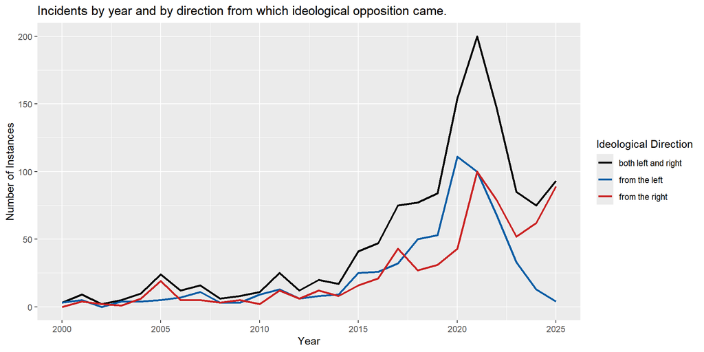

## How do topics involved in targeting incidents differ by ideology?

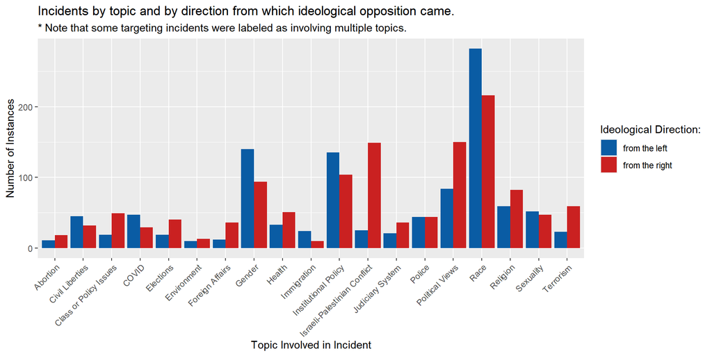

## Example targeting incident #1 – from the left

Harvard University | 2023 | Anti-Abortion Views

- Professor signed a court briefing that expressed views against abortion
- Students at the university requested for his tenure to be rescinded, for him to no longer teach a course he was scheduled for, and for the university to speak out publicly about the issue
- Professor was not officially sanctioned by the university

## Example targeting incident #2 – from the right

University of Notre Dame | 2022 | Pro-Abortion Views

- Professor’s advocacy for students’ abortion rights conflicted with the university’s religious ideology
- Student newspaper wrote that professor was “offering abortion assistance” to students
- Professor filed a defamation lawsuit against the newspaper, which was eventually dismissed
- An alumni group then suggested that the professor was not a “suitable member of the faculty”, although she was never officially sanctioned by the university

## Key takeaways

- In both of these example incidents, the professor’s academic freedom should not have been threatened based on the expression of these beliefs on abortion
- Data indicates that incidents from left and right occur at around the same rate

  | From the left: | From the right: |
  | --- | --- |
  | 605 targeting incidents | 653 targeting incidents |